# F3.2: come teniamo da parte dati veri mai usati per verificare il simulatore, e con quali regole lo cambiamo?

geo_spatialtrans, report di step (protocollo v2)

Published

November 19, 2026

## In breve: come teniamo da parte dati veri mai usati per verificare il simulatore, e con quali regole lo cambiamo?

**A cosa serviva.** Ogni numero del simulatore viene da una sola sezione per tessuto, e quasi sempre dalle stesse aree su cui poi lo abbiamo verificato: una verifica così conferma per costruzione. Questo step non ha toccato il simulatore. Ha contato da dove viene ogni valore, ha messo da parte dati veri mai usati, e ha scritto le regole per accettare un cambiamento senza adattare il simulatore a sei sezioni.

**Cosa abbiamo trovato.**

1. **380 dei 478 valori che il simulatore usa vengono dalle stesse 30 aree su cui li abbiamo verificati, una sezione per tessuto.**
   - Gli altri vengono dai bordi del tessuto o dalla sezione intera (lo spostamento dei trascritti e le strisce della griglia) oppure sono impostazioni.
   - Nessuno script dei passi precedenti legge aree che non abbiamo censito.
2. **Abbiamo 48 aree vere di verifica in otto tessuti, ma sono poche proprio dove servirebbero di più.**
   - Altri pazienti dello stesso tumore del colon (i pazienti 1 e 5): 7 aree di tumore e 4 di stroma; un secondo tumore del colon, di paziente non noto: 5 di tumore e 3 di stroma; una seconda sezione di cervello di topo: 4 aree.
   - Due tessuti mai visti, il rene umano e il fegato di ratto: 10 aree, per verificare le parti tecniche comuni a tutti i tessuti, come lo spostamento dei trascritti.
   - Intestino di topo, linfonodo e cuore non hanno una seconda sezione pubblica. Restano aree nuove della stessa sezione: 4 nell’intestino, 5 nel cuore, 2 follicoli nel linfonodo (in aree di 500 µm, perché lontano dalle aree già usate c’è soprattutto grasso), nessuna di paracorticale. Lo stroma del tumore originale non ne ha nessuna.
   - Tutti i file scaricati sono integri, e cambiare versione del programma di 10x tra i pazienti sposta i conteggi di circa l’1 %: trascurabile.
3. **Le aree le ho scelte io, ma non come previsto: due regole automatiche sui marcatori hanno fallito la loro prova sulle aree già approvate, e la terza funziona solo sulle sezioni che conosce.**
   - Le aree tenute sono quelle su cui concordano la regola (dove funziona) e due letture a vista indipendenti dell’immagine: la mia e quella di un secondo lettore che non sapeva nulla delle altre. I due lettori concordano su 9 aree su 10.
   - Nessuno dei due è un patologo: fermano gli errori grossolani (grasso, muscolo, mucosa normale mescolata al tumore), non quelli sottili.
4. **Con l’obiettivo scritto come intervallo, oggi il simulatore risulta fuori quasi ovunque.**
   - La regola dice che i dati veri devono cadere dentro la variabilità delle aree simulate. Sui dati già usati solo 13 aree vere su 240 ci cadono: le aree simulate di un tessuto si somigliano molto più delle vere, perché il simulatore usa una sola composizione e una sola densità per tessuto.
   - La semina a compartimenti più che raddoppia la variabilità fra aree simulate, ma resta circa un terzo di quella vera.
5. **Il simulatore potrebbe essere sovradattato alle aree su cui è stato tarato, ma non l’abbiamo ancora misurato.**
   - Per ogni tessuto il simulatore usa da 40 a 80 valori stimati sulle sue 5 aree di una sola sezione (una parte derivata dagli altri), più i profili di espressione presi dalle stesse aree.
   - Almeno una conferma della prima prova dei metodi di analisi era costruita: i trascritti per cellula tornavano in tutti e sei i tessuti perché il fattore di profondità era stato ritarato proprio su quella grandezza, sulle stesse aree.
   - I sintomi sono compatibili con due cause diverse: il simulatore va bene sulle aree di taratura e peggio altrove (sovradattamento: si tolgono parametri per tessuto e si stima su più sezioni), oppure va male allo stesso modo dentro e fuori (manca la variabilità fra aree e fra pazienti: si cambia il modello). Solo una misura fuori campione distingue le due.

**Cosa devi decidere.**

1. **Adottiamo le regole contro il sovradattamento? Consiglio di sì.**
   - I dati di verifica non entrano mai nella taratura e si leggono solo dopo aver scritto le previsioni; un cambiamento si accetta se ha un meccanismo documentato, al più due parametri nuovi, comuni ai tessuti quando sono tecnici, se migliora almeno 4 tessuti su 6 senza peggiorarne nessuno e se regge sui dati di verifica; se non regge non si ritocca; al più tre indagini a posteriori per step; ogni insieme di dati di verifica giudica al più tre cambiamenti, poi diventa dato di taratura.
   - Nessuna condizione si sospende perché oggi boccia: se boccia per un difetto noto, si corregge il difetto.
   - Alternativa: regole più strette, per esempio una sola lettura dei dati di verifica per insieme. Più sicura, ma con così pochi dati veri li consumeremmo subito.
2. **Prima di cambiare qualunque cosa nel simulatore, uno step a parte misura il simulatore di oggi fuori campione. Consiglio di sì.**
   - I due metodi di analisi sulle 48 aree vere di verifica, confrontati con le simulazioni che abbiamo già: quanto peggiora il simulatore passando dalle aree di taratura alle aree nuove, agli altri pazienti, ai tessuti nuovi.
   - In più quanto variano fra loro i pazienti veri dello stesso tumore rispetto alle aree di un paziente: è la variabilità che il simulatore dovrebbe saper coprire.
   - La prova della semina a compartimenti viene dopo, e solo se la misura non dice che il problema è un altro.
   - Alternativa, che avevo proposto prima e ritiro: provare subito i compartimenti, sospendendo la condizione sulla variabilità fra aree. Avrebbe nascosto il sintomo invece di misurarlo.
3. **Chiudiamo lo step anche se le prove delle due prime regole sulle aree sono fallite come scritte? Consiglio di sì.**
   - Le prove hanno fatto il loro lavoro: hanno impedito di usare regole che sbagliavano. Nessun dato e nessun risultato dipende da quelle regole.
   - Alternativa: cercare una regola automatica che passi. Sarebbe il quarto tentativo sulle stesse 30 aree.

**Comunque**

- Quando proveremo un cambiamento, le previsioni sui dati di verifica si scriveranno prima di leggerli, e ogni lettura si annoterà in un registro.
- Nei confronti con i pazienti 1 e 5 useremo solo i geni che le due versioni del programma di 10x hanno in comune: la revisione indipendente ha trovato che l’1 % di differenza è la somma di due effetti opposti, geni in più in una versione e qualche trascritto in meno sugli altri.
- Per intestino, linfonodo e cuore scriveremo «verificato solo dentro la sezione»; il secondo tumore conta come altro paziente solo se un giorno sapremo chi è.
- Le aree poche (stroma originale, paracorticale del linfonodo, cervello) restano in coda insieme al modo di averne di più.

**Sui tempi di calcolo.** Li ho misurati io sul server: scaricare e controllare i 138 GB dei dati di verifica ha richiesto poco più di un’ora; tutte le altre prove di questo step da pochi minuti a un quarto d’ora ciascuna. Lo step che misura il simulatore fuori campione costerebbe, secondo la mia stima, circa due ore e mezza per far girare i due metodi sulle 48 aree vere (nella prima prova dei metodi le 30 aree vere ne avevano richiesta una e mezza), senza simulazioni nuove. La prova dei compartimenti, quando verrà, circa 9 ore con 6 processi o poco più di 2 con 24 (dai tempi della prima prova dei metodi: circa 3,5 simulazioni con i due metodi per processore all’ora).

# Dubbi rinviati

| cosa | perché | cosa serve per chiuderlo | step destinatario | voce di BACKLOG |
| --- | --- | --- | --- | --- |
| Poche aree di verifica dove servirebbero: stroma originale 0, paracorticale del linfonodo 0, cervello originale 1, linfonodo 2 follicoli di 500 µm | lontano dalle aree di R2 c’è poco tessuto adatto; linfonodo, intestino e cuore non hanno seconde sezioni FFPE pubbliche | nuovi dataset pubblici 10x (controllare l’inventario a ogni rilascio) o riduzione delle aree di taratura | da assegnare | BL-266 |
| La terza regola sui marcatori non si trasferisce fra sezioni (kappa con i lettori 0,26 contro 0,78) | punteggi assoluti dipendono da profondità, versione e paziente | una normalizzazione per sezione provata fuori campione, se un giorno serve scegliere aree in automatico | da assegnare | BL-267 |
| Paziente del tumore da 6,5 mm non noto; XIST non è nel pannello di sonde e i geni del cromosoma Y non distinguono | per ora conta solo come sezione, non come altro paziente | metadati da 10x o confronto di varianti, non possibile con sonde | da assegnare | BL-268 |
| Geni diversi fra Space Ranger 3.0.0 e 4.0.1 (18 107 comuni) | il +0,9 % di P-1 è la somma di due effetti opposti | usare i geni comuni in ogni confronto con P1 e P5 | prova della semina a compartimenti | BL-269 |
| Con l’obiettivo come intervallo, la condizione «vero dentro la variabilità del simulato» oggi boccia tutto (13 aree vere su 240) | una sola composizione e densità per tessuto (BL-262) | passo che produce la variabilità fra aree, poi la condizione si applica | dopo la prova della semina a compartimenti | BL-262, BL-270 |

# Cancelli e previsioni

Pre-registrazione: cancelli e previsioni `1a7c698`; ok di Luca sulle previsioni del 2026-11-18, `cdd6034` (DEC-091). Modifiche dichiarate durante lo step: seconda regola delle aree `43a0c68` (DEC-092), distanza delle aree nuove `696bced` (DEC-094), scelta delle aree da parte dell’agente `c7a8297` (DEC-095). Errore di pre-registrazione: G-3 chiedeva 6 sezioni di taratura, sono 5.

| id | tipo | tessuto | atteso | intervallo (fonte) | osservato | esito | spiegazione |
| --- | --- | --- | --- | --- | --- | --- | --- |
| G-1 | cancello | tutti | censimento completo e fedele | 1e-9 relativo; 2 mutanti | 478 valori uguali al pacchetto; 0 senza fonte o aree; mutanti 2/2 | PASS | `tools/F3.2_test.py G-1` |
| G-2 | cancello | tutti | md5 o ETag; md5 di taratura invariati | uguaglianza esatta | 46/46 file (36 md5, 10 ETag); 82 file di taratura identici prima e dopo, 57 uguali ai registri di R1 e F3.1 | PASS |  |
| G-3 | cancello | 5 sezioni di taratura | PASS e 3 guasti rilevati | esatta | 5/5 PASS; scala e rotazione 5/5; troncamento a metà 4/5 (tumore: tessuto tutto nella metà superiore), troncamento al centro del tessuto 5/5 | PASS | le 6 sezioni di verifica passano tutte |
| G-4 (a-c) | cancello | tutti | mappa, distanze, fuga | conteggi esatti; 280 µm | 30, 24, 314 righe; distanza minima 280,4 µm dalle aree di R2 e 291,5 µm fra aree; 0 occorrenze fuori dai lettori ammessi; mutante rilevato | PASS | distanza dalle aree di R2 (DEC-094) |
| G-4 (d) | cancello | aree di R2 | prima regola: classe giusta ≥ 28/30 |  | 12/30 | **FALLITO come scritto** | soglia relativa ai gruppi di Space Ranger, classe del quadratino, filtro dei lumi |
| G-4 (d’) | cancello | aree di R2 | seconda regola: ≥ 28/30, negativi ≥ 14/15, filtri ≥ 28/30, ritaglio scartato |  | 18/30; 15/15; 30/30; scartato | **FALLITO come scritto** (i) | insiemi quasi assenti (cuore), fattore 2 più stretto della variabilità vera (tumore, cervello) |
| G-5 | cancello | tutti | ricalcolo indipendente | tolleranze dei cancelli | 13 controlli, 0 discrepanze | PASS | vedi «Revisione avversariale» |
| P-1a | previsione | tumore del colon | 0 | ±0,052 (B-280, R7, /4) | +0,0088 [+0,0081; +0,0096] | confermata | UMI per quadratino, 3.0.0 contro 4.0.1 |
| P-1b | previsione | tumore del colon | 0 | ±0,176 | −0,0147 [−0,0206; −0,0088] | confermata | quadratini vuoti |
| P-1c | previsione | tumore del colon | 0 | ±0,052 (B-282) | +0,0094 [+0,0087; +0,0101] | confermata | geni per quadratino |
| P-1d | previsione | stroma del tumore | 0 | ±0,048 (B-290) | +0,0091 [+0,0068; +0,0114] | confermata |  |
| P-1e | previsione | stroma del tumore | 0 | ±0,090 | −0,0119 [−0,0299; +0,0061] | confermata |  |
| P-1f | previsione | stroma del tumore | 0 | ±0,048 (B-292) | +0,0087 [+0,0076; +0,0098] | confermata |  |

Intervalli: media delle 5 aree ± 2 errori standard fra aree × κ di R7 (1,655 nel tumore, 3,193 nello stroma). Fonte: `results/F3.2/F3.2_bridge_predictions.csv`.

# Controprova

- **CP-1, nessuna lettura dei dati veri fuori dalla mappa**: 146 script che leggono i dati veri o le cartelle derivate, tutti classificati (`results/F3.2/F3.2_readers.csv`): 73 sulle aree di R2, 12 sulle finestre, 5 sulle tessere di bordo, 23 sulla sezione intera, il resto integrità, lanci e strumenti di F3.2. Confermata.
- **CP-2, cambio di versione**: le previsioni P-1, tutte confermate.

# Censimento e regola dell’obiettivo

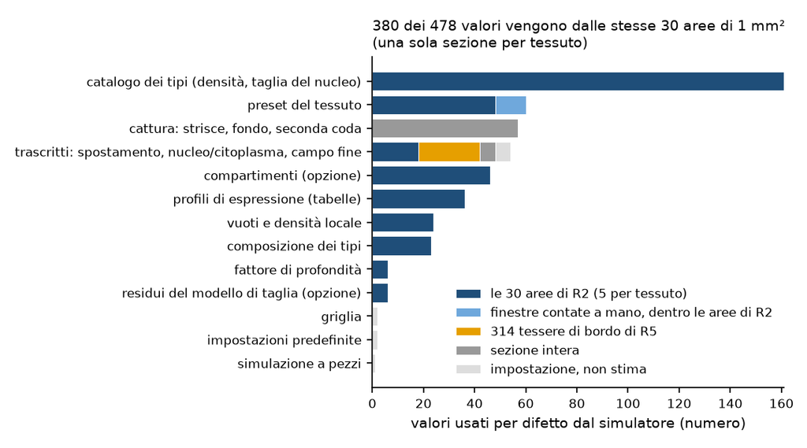

Da dove vengono i valori che il simulatore usa per difetto. **Cosa guardare**: quasi tutta la barra è blu scuro, le 30 aree di R2.

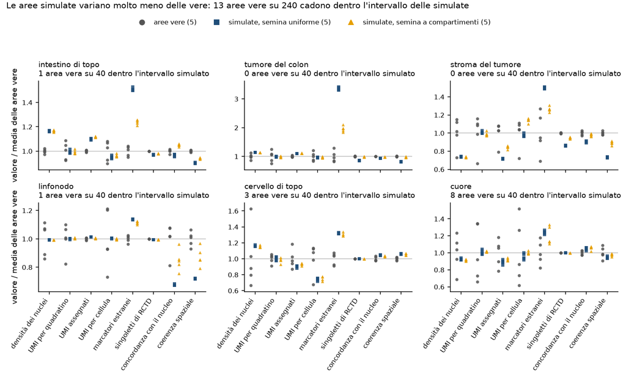

Prova a secco dell’obiettivo come intervallo sui soli dati di taratura di F3.1 (valori divisi per la media delle aree vere). **Cosa guardare**: i quadrati blu e i triangoli arancio sono quasi sovrapposti, i cerchi grigi sparsi: la condizione «vero dentro la variabilità del simulato» boccia per costruzione.

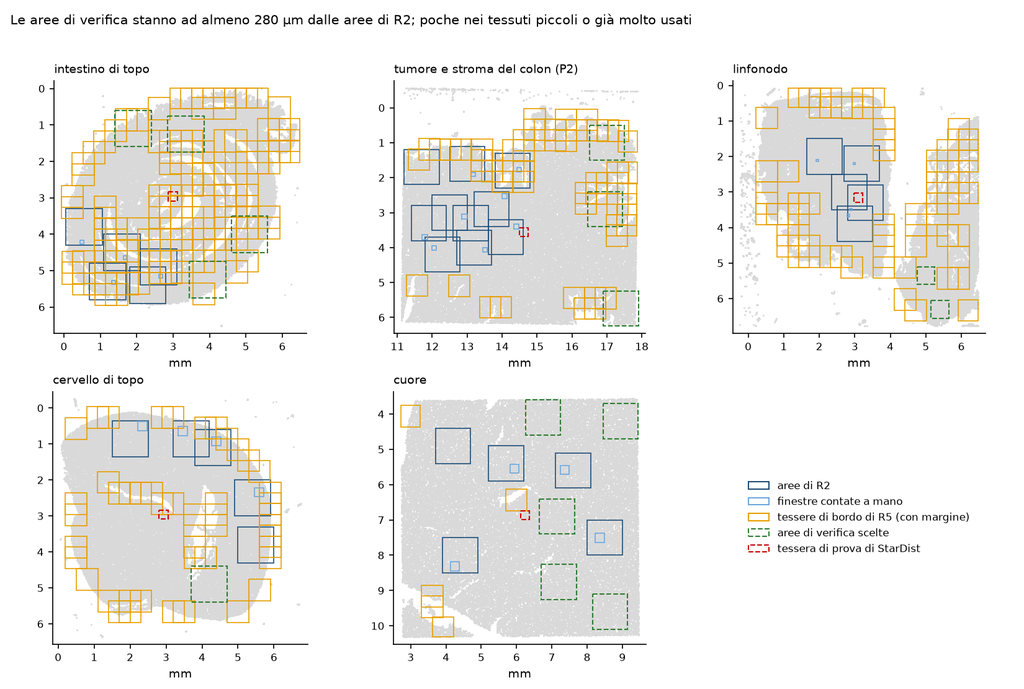

Aree usate dagli step passati e aree di verifica scelte nelle sezioni di taratura. **Cosa guardare**: nel linfonodo e nel cervello restano pochissime aree verdi.

# Scelta delle aree di verifica

Il confronto a vista di Luca è stato ritirato (DEC-095). Due regole automatiche hanno fallito la prova sulle aree di R2 (12 e 18 su 30); la terza (26 su 30, non cieca) funziona sulle sezioni di taratura ma non si trasferisce alle altre (kappa con i lettori 0,78 contro 0,26). Le aree tenute sono quelle su cui concordano regola e due lettori a vista (l’agente, registrato prima della terza regola, e un sotto-agente alla cieca) sulle sezioni di taratura e sui tessuti nuovi, e i due lettori sulle altre sezioni dello stesso tessuto. Accordo fra i lettori 0,907, kappa 0,882 su 107 candidate. Tabella completa: `results/F3.2/F3.2_area_agreement.csv`; coordinate: `results/F3.2/F3.2_selected_*.csv`.

| livello | sezione | classe | aree |
| --- | --- | --- | --- |
| L1 | intestino di topo | mucosa | 4 |
| L1 | tumore del colon (P2) | tumore | 3 |
| L1 | tumore del colon (P2) | stroma | 0 |
| L1 | linfonodo (500 µm) | follicolo | 2 |
| L1 | linfonodo (500 µm) | paracorticale | 0 |
| L1 | cervello di topo | corteccia | 1 |
| L1 | cuore | miocardio | 5 |
| L2 | tumore P1 | tumore, stroma | 4, 3 |
| L2 | tumore P5 | tumore, stroma | 3, 1 |
| L2 | tumore 6,5 mm (paziente incerto) | tumore, stroma | 5, 3 |
| L2 | cervello di topo, seconda sezione | corteccia | 4 |
| L3 | rene umano | tessuto | 5 |
| L3 | fegato di ratto | tessuto | 5 |

Prova del lato dell’area (solo dati di taratura, `results/F3.2/F3.2_size_check.csv`): 20 casi su 24 entro un quarto della variabilità fra aree (19 su 23 informativi), tutti e 4 nel linfonodo. Paziente del tumore da 6,5 mm (`results/F3.2/F3.2_sexcheck.csv`): XIST assente dal pannello, geni del cromosoma Y 1,1, 0, 0 e 3,7 UMI per 10 000 in P2, P1, P5 e 6,5 mm: non decidibile.

# Lettura di Luca

Dopo il primo riassunto Luca ha scritto: «fermo fermo fermo. Io vedo un bel disastro nei primi 5 punti. Overfitting problematico e quelli sono i sintomi. Sei sicuro di voler andare avanti?». L’agente ha ritirato la raccomandazione di provare subito la semina a compartimenti sospendendo la condizione sulla variabilità fra aree, e ha proposto una misura del simulatore di oggi fuori campione prima di ogni modifica. Luca: «ok l’ordinr e la sessione separata. Chiudi» (DEC-096). Il riassunto in testa è la versione corretta.

# Revisione avversariale

Un sotto-agente indipendente, con codice proprio e in sola lettura sul server, ha ricalcolato: 20 valori del censimento estratti con seme 20261118 (20/20 uguali al pacchetto), la quota 380 su 478, md5 ed ETag di 3 file, le aree usate per sezione, P-1 per area e per tessuto (differenze relative ≤ 4e-13), accordo e kappa delle letture, le 48 aree tenute, la prova del lato dell’area. Nessuna discrepanza numerica. Due osservazioni accolte: il +0,9 % di P-1 è la somma di due effetti opposti, geni in più nella 3.0.0 e −0,5 % sui geni comuni (BL-269, regola R-8); nel cuore i singoletti valgono 1 ovunque, quindi la prova del lato passa per costruzione in quel caso (19 su 23 casi informativi). Risultato completo: `results/F3.2/F3.2_adversarial_review.json`.

# Cosa è girato

Ramo `f3-methods`; strumenti `tools/F3.2_*` (scaricamento, censimento in R e in Python, aree, compatibilità, StarDist, ponte di versione, controllo di fuga, censimento dei lettori, prova a secco, terza regola, prova del lato, controllo del sesso, selezione, figure, batteria, md5). Semi: 20261118 per estrazioni e revisione. Dati di verifica: 46 file, 137,8 GB su `/mnt/micron/geo_spatialtrans/data_holdout` e `data_bridge`, scaricati in circa un’ora e un quarto. Grandezze derivate dai dati di verifica in `/mnt/micron/geo_spatialtrans/F3.2_sealed`. md5 dei dati di taratura letti: `results/F3.2/F3.2_md5_before.txt` e `_after.txt`, identici (82 file). Batteria: `python3 tools/F3.2_test.py all` (fallisce solo su G-4 d e d’, falliti come scritti).

# Appendice

## Da dove vengono i numeri del riassunto

| frase del riassunto | fonte (tabella o file, riga) | valore letto |
| --- | --- | --- |
| 380 dei 478 valori dalle stesse 30 aree | `results/F3.2/F3.2_census.csv`, area_set in R2_ROI o R2b_WINDOW | 368 + 12 = 380 su 478 |
| nessuno script legge aree non censite | `results/F3.2/F3.2_readers.csv` | 146 script, 0 non classificati |
| 48 aree in otto tessuti | `results/F3.2/F3.2_area_agreement.csv`, kept | 48 (L1 15, L2 23, L3 10) |
| pazienti 1 e 5: 7 di tumore e 4 di stroma | stesso file, sheet CRC_P1_SR300 e CRC_P5_SR300 | tumore 4 + 3, stroma 3 + 1 |
| secondo tumore: 5 di tumore e 3 di stroma; secondo cervello 4 | stesso file | 5, 3, 4 |
| rene e fegato 10 aree | stesso file | 5 + 5 |
| intestino 4, cuore 5, linfonodo 2 follicoli di 500 µm, paracorticale 0, stroma originale 0 | stesso file, livello L1 | 4, 5, 2, 0, 0 |
| file integri | `data/holdout/F3.2_download_status.csv` | 46 OK su 46 |
| circa l’1 % fra versioni | `results/F3.2/F3.2_bridge_predictions.csv` | da +0,0087 a +0,0094 (UMI e geni), −0,012 e −0,015 (vuoti) |
| due regole fallite | `results/F3.2/F3.2_rule_validation.csv`, `F3.2_rule2_validation.csv` | 12/30, 18/30 |
| la terza funziona solo sulle sezioni che conosce | `results/F3.2/F3.2_area_agreement.csv` | kappa con il lettore 0,78 (taratura), 0,26 (altre sezioni) |
| i due lettori concordano su 9 aree su 10 | stesso file | 0,907 (97/107), kappa 0,882 |
| 13 aree vere su 240 | `results/F3.2/F3.2_R4_dryrun.csv`, arm sim | 13 su 240 |
| compartimenti: più che raddoppia, circa un terzo | stesso file, rapporto mediano delle DS | 0,124 (uniforme), 0,299 (compartimenti) |
| un’ora e un quarto per scaricare | job di scaricamento, primo file 13:31, fine con estrazione 14:40 (2026-11-18) | circa 1 h 10 min |
| 3,5 simulazioni per processore all’ora | F3.1, riassunto: 85 simulazioni con i due metodi in circa 4 ore con 6 processi | 85 / (4 × 6) ≈ 3,5 |